# Temperature Anomalies, Snow Albedo and Surface Energy Balance in Alaska

**General Note 1**: Execute each cell through the button from the top MENU (or keyboard shortcut `Shift` + `Enter`).  
**General Note 2**: If, for any reason, the kernel is not working anymore, in the top MENU, click on the button.

- 1. Introduction
- 2. Setting up the R environment
- 3. Data Download
  - 3.1. Presentation of the product used
  - 3.2. Downloading the product
- 4. Exploring the dataset
- 5. Monthly climatologies and anomalies
  - 5.1. Monthly climatologies
  - 5.2. Monthly anomalies maps with 2019
- 6. From snow albedo and surface energy balance
  - 6.1. Comparison between different variables
  - 6.2. Evolution of temperature anomaly in June
- 7. Exercices
- 8. Conclusion

# 1. Introduction

Go back to the "Table of contents"

The objective of this study is to explore the impacts of climate change and rising temperatures on the Arctic environment, with a particular focus on Alaska. The analysis will use ERA5 reanalysis data to investigate temperature variations and their potential effects on the surface energy balance. Particular attention will be given to the spring–summer transition, when changes in snow cover and surface properties can influence the amount of solar energy absorbed by the surface. The study will explore the relationships between temperature, snow albedo, surface radiation and soil temperature, with a focus on exceptionally warm years such as 2019. This analysis aims to provide a better understanding of how changes in the Arctic environment can interact and potentially contribute to further warming.

# 2. Setting up the R environment

Go back to the "Table of contents"

The Jupyter Notebook must be set up with all the necessary available tools from the Jupyter Notebook ecosystem. Here is the list of the modules we will be using in this exercise.

| Module name | Description |
| --- | --- |
| **ggplot2** | [ggplot2](https://ggplot2.tidyverse.org/) is a system for declaratively creating graphics. |
| **dplyr** | [dplyr](https://dplyr.tidyverse.org/) is a library for manipulating data. |
| **ncdf4** | [ncdf4](https://cran.r-project.org/web/packages/ncdf4/index.html) is an interface for the 'NetCDF' file formats. |
| **gridExtra** | [gridExtra](https://cran.r-project.org/web/packages/gridExtra/index.html) is a library for arranging multiple grid-based plots on a page. |
| **lubridate** | [lubridate](https://www.rdocumentation.org/packages/lubridate/versions/1.9.3) is a library for fast and user-friendly analysis of date-time data. |
| **rnaturalearth & rnaturalearthdata** | [rnaturalearth](https://cran.r-project.org/web/packages/rnaturalearth/vignettes/rnaturalearth.html) is a data package designed to provide map data . |
| **sf** | [sf](https://cran.r-project.org/web/packages/sf/index.html) is a package for standardized way to encode and analyze spatial vector data. |

|**hdar**|[hdar](https://cran.r-project.org/web/packages/hdar/index.html) is an R package providing a standardized way to access and download data from the Arctic Hub data store.

```r
# Modules system
# for ignoring Warning message
options(warn = -1)

## Load Packages
suppressPackageStartupMessages({
    library(ggplot2)          # Create graphics and maps
    library(dplyr)            # Data manipulation and transformation
    library(gridExtra)        # Arrange multiple plots on a page
    library(lubridate)        # Work with dates and times
    library(sf)               # Handle and manipulate spatial vector data
    library(rnaturalearth)    # Access Natural Earth geographical data
    library(rnaturalearthdata)# Provides Natural Earth map datasets
    library(hdar)             # To access and download data from the Arctic Hub
    library(ncdf4)          # High-level interface to netCDF data files

})
```

If the required R libraries are not installed, you can use the following command to install them:

#### install.packages(c("ggplot2", "dplyr", "ncdf4", "gridExtra", "lubridate", "rnaturalearth","rnaturalearthdata","sf","hdar"))

## 3. Data Download

Go back to the "Table of contents"

### 3.1. Presentation of the product used

Go back to the "Table of contents"

From the Copernicus Arctic Hub [Data Viewer](https://data.arctic.hub.copernicus.eu/data), you can explore all the products available with many filters to select the region you are interested in, the parameters you want to study, etc.

In this notebook, we are going to mainly use the ["ERA5 monthly averaged data on single levels"](https://data.arctic.hub.copernicus.eu/data?view=dataset&dataset=EO%3AECMWF%3ADAT%3AREANALYSIS_ERA5_SINGLE_LEVELS_MONTHLY_MEANS) product from ECMWF. It originates from a computer model that simulates ocean, sea and land all around the world. By blending the laws of physics with real-world data from satellites and sensors, it generates accurate monthly updates on ice, temperature ...

From this product, we retrieve different variables.

[output not shown]

[figure not shown]

## 3.2. Downloading the product

Go back to the "Table of contents"

First, we defined the username and password:

```r
username <- "your_username"
password <-"your_password"

client <- Client$new(
    username,password,
    save_credentials = TRUE
)
```

```
hdar 1.0.7
```

Once the credentials are saved, you can initialize the Client without passing the credentials.

```r
client <- Client$new()
```

The query is specific, it should be a JSON string that defines the parameters for the data search, including dataset ID, product type, variables, date,.... To have more information about the input that you could put in the query you could use this command line, in putting the dataset ID:

```r
client$generate_query_template("EO:ECMWF:DAT:REANALYSIS_ERA5_SINGLE_LEVELS_MONTHLY_MEANS")
```

```
{
  "dataset_id": "EO:ECMWF:DAT:REANALYSIS_ERA5_SINGLE_LEVELS_MONTHLY_MEANS",
  "product_type": ["monthly_averaged_reanalysis", "monthly_averaged_reanalysis_by_hour_of_day", "monthly_averaged_ensemble_members", "monthly_averaged_ensemble_members_by_hour_of_day"],
  "variable": ["10m_u_component_of_wind", "10m_v_component_of_wind", "2m_dewpoint_temperature", "2m_temperature", "mean_sea_level_pressure", "mean_wave_direction", "mean_wave_period", "sea_surface_temperature", "significant_height_of_combined_wind_waves_and_swell", "surface_pressure", "total_precipi…
  "year": ["1940", "1941", "1942", "1943", "1944", "1945", "1946", "1947", "1948", "1949", "1950", "1951", "1952", "1953", "1954", "1955", "1956", "1957", "1958", "1959", "1960", "1961", "1962", "1963", "1964", "1965", "1966", "1967", "1968", "1969", "1970", "1971", "1972", "1973", "1974", "1975", "…
  "month": ["01", "02", "03", "04", "05", "06", "07", "08", "09", "10", "11", "12"],
  "time": ["00:00", "01:00", "02:00", "03:00", "04:00", "05:00", "06:00", "07:00", "08:00", "09:00", "10:00", "11:00", "12:00", "13:00", "14:00", "15:00", "16:00", "17:00", "18:00", "19:00", "20:00", "21:00", "22:00", "23:00"],
  "bbox": [
    -180,
    -90,
    180,
    90
  ],
  "data_format": "grib",
  "_comment_data_format": "One of",
  "_values_data_format": ["grib", "netcdf"],
  "download_format": "unarchived",
  "_comment_download_format": "One of",
  "_values_download_format": ["unarchived", "zip"]
}
```

Now, that is the query that we need:

```r
query_1 <- '{
  "dataset_id": "EO:ECMWF:DAT:REANALYSIS_ERA5_SINGLE_LEVELS_MONTHLY_MEANS",
  "product_type": [
    "monthly_averaged_reanalysis"
  ],
  "variable": [
    "2m_temperature",
    "soil_temperature_level_1",
    "snow_albedo"
  ],
  "year": [
    "2000","2001","2002","2003","2004","2005","2006","2007","2008","2009","2010","2011","2012",
    "2013","2014","2015","2016","2017","2018","2019","2020","2021","2022","2023","2024","2025"],
  "month": ["01","02","03","04","05","06","07","08","09","10","11","12"],
  "time": ["00:00"],
  "bbox": [-170,51,-130,72],
  "data_format": "netcdf",
  "download_format": "unarchived",
  "itemsPerPage": 200,
  "startIndex": 0
}'

query_2 <- '{
  "dataset_id": "EO:ECMWF:DAT:REANALYSIS_ERA5_SINGLE_LEVELS_MONTHLY_MEANS",
  "product_type": [
    "monthly_averaged_reanalysis"
  ],
  "variable": [
    "surface_net_solar_radiation",
    "surface_solar_radiation_downwards",
    "snowmelt"
  ],
  "year": [
    "2000","2001","2002","2003","2004","2005","2006","2007","2008","2009","2010","2011","2012",
    "2013","2014","2015","2016","2017","2018","2019","2020","2021","2022","2023","2024","2025"],
  "month": ["01","02","03","04","05","06","07","08","09","10","11","12"],
  "time": ["00:00"],
  "bbox": [-170,51,-130,72],
  "data_format": "netcdf",
  "download_format": "unarchived",
  "itemsPerPage": 200,
  "startIndex": 0
}'
```

```r
# Assuming 'client' is already created and authenticated
matches_1 <- client$search(query_1)
matches_2 <- client$search(query_2)
```

```
Found 1 files

Total Size 0 B

Found 1 files

Total Size 0 B
```

Now you define the output directory where the downloaded files will be saved.

```r
# output directory where the downloaded files will be saved
output_directory <- "./data/"

# if the output directory does not exist, create it
dir.create(
  output_directory,
  showWarnings = FALSE,
  recursive = TRUE
)
```

```r
# dowload the data files to the specified output directory
matches_1$download(output_directory)
matches_2$download(output_directory)
```

# 4. Exploring the dataset

Go back to the "Table of contents"

We have downloaded the needed data. The location of the file is: `data/`. Let's now open it using the **netcdf4** library.

```r
# Set the path for the NetCDF files
file <- "./data/reanalysis-era5-single-levels-monthly-means-b11a1433282588ae743ec586549eab39.nc"
```

```r
# Load NetCDF File
data <- nc_open(file)
```

```r
# Access Data
latitude <- ncvar_get(data, "latitude")  # Name of the latitude variable
longitude <- ncvar_get(data, "longitude")  # Name of the longitude variable

time <- ncvar_get(data, "valid_time")  # Name of the time variable
time_values <- as.POSIXct(time, origin = "1970-01-01", tz = "GMT")

stl1 <- ncvar_get(data, "stl1") -273.15# Soil temperature at level 1 (approximately 0–7 cm depth) - we do -273.15 to convert from Kelvin to Celsius
t2m<- ncvar_get(data, "t2m")-273.15  # 2-metre air temperature - we do -273.15 to convert from Kelvin to Celsius
asn<- ncvar_get(data, "asn")  # Snow albedo
```

```r
# Print time to verify that the time variable has been correctly converted to POSIXct format
time_values[1:10]
```

```
 [1] "2000-01-01 GMT" "2000-02-01 GMT" "2000-03-01 GMT" "2000-04-01 GMT"
 [5] "2000-05-01 GMT" "2000-06-01 GMT" "2000-07-01 GMT" "2000-08-01 GMT"
 [9] "2000-09-01 GMT" "2000-10-01 GMT"
```

```r
# we choose a specific time index to extract data for that time step
index_time=5

# we extract the data for the chosen time step
stl1_int=stl1[,,index_time]
t2m_int=t2m[,,index_time]
asn_int=asn[,,index_time]

# we create a dataframe
df <- data.frame(expand.grid(longitude, latitude,time_values),
                 t2m = as.vector(t2m_int),asn = as.vector(asn_int),stl1=as.vector(stl1_int))


names(df) <- c("Longitude", "Latitude","time","t2m", "asn","stl1")

# visualisation of the dataframe
df[1:10,]
```

A data.frame: 10 × 6

|  | Longitude <dbl[1d]> | Latitude <dbl[1d]> | time <dttm[1d]> | t2m <dbl> | asn <dbl> | stl1 <dbl> |
| --- | --- | --- | --- | --- | --- | --- |
| 1 | -170.00 | 72 | 2000-01-01 | -6.441260 | 0.8799969 | -6.289893 |
| 2 | -169.75 | 72 | 2000-01-01 | -6.447119 | 0.8799969 | -6.295752 |
| 3 | -169.50 | 72 | 2000-01-01 | -6.464697 | 0.8799969 | -6.311377 |
| 4 | -169.25 | 72 | 2000-01-01 | -6.484229 | 0.8799969 | -6.325049 |
| 5 | -169.00 | 72 | 2000-01-01 | -6.499854 | 0.8799969 | -6.336768 |
| 6 | -168.75 | 72 | 2000-01-01 | -6.517432 | 0.8799969 | -6.346533 |
| 7 | -168.50 | 72 | 2000-01-01 | -6.535010 | 0.8799969 | -6.356299 |
| 8 | -168.25 | 72 | 2000-01-01 | -6.552588 | 0.8799969 | -6.366064 |
| 9 | -168.00 | 72 | 2000-01-01 | -6.568213 | 0.8799969 | -6.373877 |
| 10 | -167.75 | 72 | 2000-01-01 | -6.591650 | 0.8799969 | -6.383643 |

```r
# We create the output directory:
dir.create("./figures/", recursive = TRUE, showWarnings = FALSE)
```

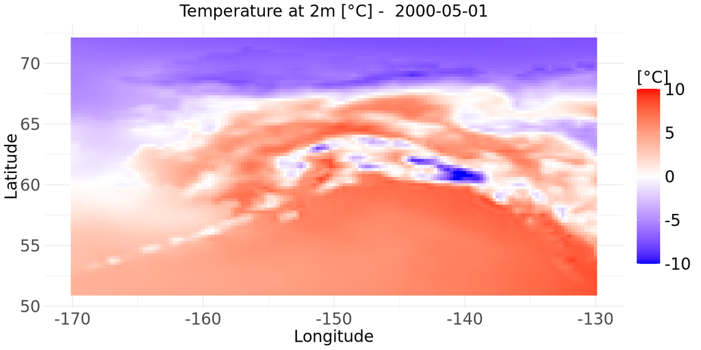

```r
# To define the dimension of the image
options(repr.plot.width = 12, repr.plot.height = 6)

# Plotting
p <- ggplot() +

# Add t2m data
geom_raster (data = df, aes(x=Longitude, y=Latitude, fill = t2m)) +

# Color scale options limits
scale_fill_gradientn(colors = c("blue", "white", "red"),values = scales::rescale(c(-10, 0, 10)), limits = c(-10,10),oob = scales::squish,name = "[°C]",na.value = "grey") +

# General aesthetic options
theme_light() +

# Title and subtitle
labs(title = paste("Temperature at 2m [°C] -  ",time_values[index_time],sep=''),
     x = "Longitude",
     y = "Latitude")+

# Legend position and aesthetic options
theme_minimal()+

theme(
    axis.text.x = element_text(size = 20),  # Increase the size of the x-axis values
    axis.text.y = element_text(size = 20),  # Increase the size of the y-axis values
    plot.title = element_text(hjust = 0.5, size = 20),  # Center and increase the size of the title
    axis.title.x = element_text(size = 20),  # Increase the size of the x-axis title
    axis.title.y = element_text(size = 20),  # Increase the size of the y-axis title
    legend.text = element_text(size = 20),    # Increase the size of the legend text
    legend.title = element_text(size = 20)     # Increase the size of the legend title
)   +

guides(fill = guide_colorbar(barwidth = 2, barheight = 15))

# to save the figure
ggsave("./figures/basic_figure_of_temperature.png", plot = p, width = 12, height = 6, dpi = 300)

p
```

We can see the 2-m air temperature in May 2000. Temperatures range from approximately −10°C to 7°C, with higher temperatures mainly observed in the southern part of the study area, particularly over the sea. However, it is difficult to clearly distinguish between land and sea on this map.

To make the map easier to interpret, we will add country borders to clearly distinguish between land and sea. First, we retrieve the country boundaries from the Natural Earth database and make sure that they use the same coordinate reference system (CRS) as our ERA5 data. We then convert the spatial boundaries into coordinates so that they can be added to our ggplot map.

```r
# Retrieve country boundaries from the Natural Earth database
countries <- ne_countries(
  scale = "medium",
  returnclass = "sf"
)

# If the CRS is missing, assign WGS84 (EPSG:4326)
if (is.na(st_crs(countries))) {
  st_crs(countries) <- 4326
}

# Convert the country boundaries from spatial features (sf)
# into a table of coordinates (X, Y)
countries_coords <- st_coordinates(countries)

# Convert the coordinates into a data frame
countries_coords <- as.data.frame(countries_coords)
```

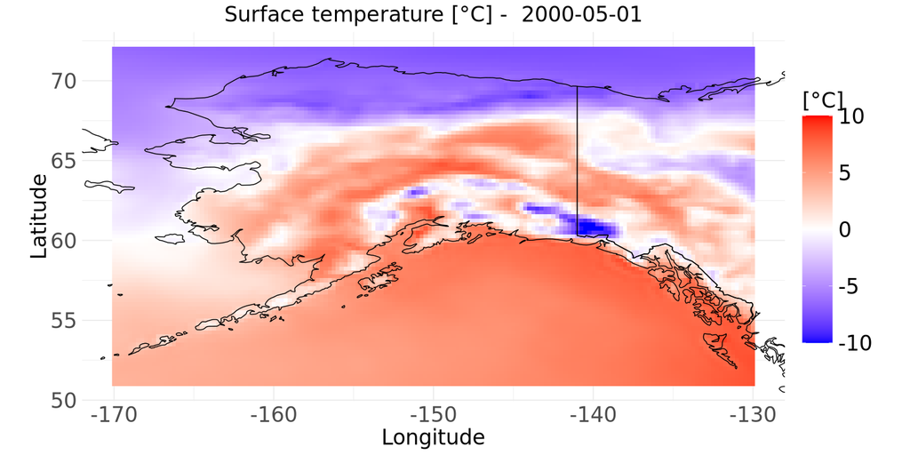

```r
# To define the dimension of the image
options(repr.plot.width = 12, repr.plot.height = 6)

# Plotting
p <- ggplot() +

# Add KD490 data
geom_raster (data = df, aes(x=Longitude, y=Latitude, fill = t2m)) +

# Country borders
geom_path(data = countries_coords,aes(x = X,y = Y,group = interaction(L1, L2, L3)), color = "black",linewidth = 0.4) +

# Limit the map to the extent of df
coord_fixed(xlim = c(min(df$Longitude, na.rm = TRUE),max(df$Longitude, na.rm = TRUE)),
    ylim = c(min(df$Latitude, na.rm = TRUE),max(df$Latitude, na.rm = TRUE))) +

# Color scale options limits
scale_fill_gradientn(colors = c("blue", "white", "red"),values = scales::rescale(c(-10, 0, 10)), limits = c(-10,10),oob = scales::squish,name = "[°C]",na.value = "grey") +

# General aesthetic options
theme_light() +

# Title and subtitle
labs(title = paste("Surface temperature [°C] -  ",time_values[index_time],sep=''),
     x = "Longitude",
     y = "Latitude")+

# Legend position and aesthetic options
theme_minimal()+

theme(
    axis.text.x = element_text(size = 20),  # Increase the size of the x-axis values
    axis.text.y = element_text(size = 20),  # Increase the size of the y-axis values
    plot.title = element_text(hjust = 0.5, size = 20),  # Center and increase the size of the title
    axis.title.x = element_text(size = 20),  # Increase the size of the x-axis title
    axis.title.y = element_text(size = 20),  # Increase the size of the y-axis title
    legend.text = element_text(size = 20),    # Increase the size of the legend text
    legend.title = element_text(size = 20)     # Increase the size of the legend title
)   +

guides(fill = guide_colorbar(barwidth = 2, barheight = 15))

p
```

With the country borders added, the different areas can be identified more clearly. A clear difference can be observed between northern and southern Alaska, with the southern part being warmer.

# 5. Monthly climatologies and anomalies

Go back to the "Table of contents"

In Alaska, temperature varies strongly throughout the year, both spatially and seasonally. The contrast between the cold winter months and the warmer spring and summer months is particularly pronounced, with significant differences between northern and southern regions. In this part of the training, we will examine the seasonal evolution of 2-m air temperature across Alaska. By comparing the spatial distribution of temperature across different months, we will identify the main seasonal patterns and temperature variations across the region.

After examining the seasonal evolution of 2-m air temperature, we will focus on 2019, a particularly warm year in Alaska. We will calculate temperature anomalies by comparing the 2019 monthly temperatures with the corresponding long-term monthly averages. These anomalies will then be represented on maps to highlight the areas and months where temperatures were significantly higher or lower than the climatological average. This will allow us to identify the most pronounced temperature anomalies during 2019.

## 5.1. Monthly climatologies

Go back to the "Table of contents"

We will examine the monthly climatology of 2-m air temperature. To do this, we will calculate the average temperature for each month over the period 2000–2025. For example, all January values will be averaged together to obtain the January climatology, then the same calculation will be performed for February, March, and so on through December. This will allow us to characterize the typical seasonal temperature cycle in Alaska.

```r
# we create a dataframe

df_climatology <- data.frame(expand.grid(longitude, latitude,time_values),
                 t2m = as.vector(t2m[,,]),stl1=as.vector(stl1[,,]),asn=as.vector(asn[,,]))

names(df_climatology) <- c("Longitude", "Latitude","time","t2m","stl1","asn")

# print the first 10 rows of the dataframe
df_climatology[1:10,]
```

A data.frame: 10 × 6

|  | Longitude <dbl[1d]> | Latitude <dbl[1d]> | time <dttm[1d]> | t2m <dbl> | stl1 <dbl> | asn <dbl> |
| --- | --- | --- | --- | --- | --- | --- |
| 1 | -170.00 | 72 | 2000-01-01 | -26.09521 | -25.25384 | 0.8799964 |
| 2 | -169.75 | 72 | 2000-01-01 | -26.00146 | -25.12688 | 0.8799964 |
| 3 | -169.50 | 72 | 2000-01-01 | -25.91747 | -25.00579 | 0.8799964 |
| 4 | -169.25 | 72 | 2000-01-01 | -25.83349 | -24.88665 | 0.8799964 |
| 5 | -169.00 | 72 | 2000-01-01 | -25.74169 | -24.75970 | 0.8799964 |
| 6 | -168.75 | 72 | 2000-01-01 | -25.64403 | -24.63079 | 0.8799964 |
| 7 | -168.50 | 72 | 2000-01-01 | -25.54638 | -24.49602 | 0.8799964 |
| 8 | -168.25 | 72 | 2000-01-01 | -25.45067 | -24.36712 | 0.8799964 |
| 9 | -168.00 | 72 | 2000-01-01 | -25.36864 | -24.27141 | 0.8799964 |
| 10 | -167.75 | 72 | 2000-01-01 | -25.29052 | -24.18157 | 0.8799964 |

```r
# add the corresponding month and year
df_climatology$month <- as.numeric(format(df$time, "%m"))
df_climatology$year <- as.numeric(format(df$time, "%Y"))
```

```r
# Statistics over each time
df_climatology_month <- df_climatology %>%
    group_by(Longitude, Latitude, month) %>%
    reframe(mean_asn = mean(asn,na.rm=TRUE),
             mean_t2m = mean(t2m,na.rm=FALSE),
             mean_stl1 = mean(stl1,na.rm=TRUE))
```

We create a function for plootting the maps, to simplify the rest of the notebook:

```r
# creation plot function
mapping_dataframe <- function(df,index_month, min_max,variable, variable_name){
    options(repr.plot.width = 12, repr.plot.height = 6)

     # Truncate the dataframe for a specific month and depth
    df_truncate <- df %>%filter(month == index_month) %>% group_by(Longitude, Latitude) %>% ungroup()

    p=ggplot() +

    # ERA5 data
    geom_tile(data = df_truncate,aes(x = Longitude,y = Latitude,fill = .data[[variable]])) +

    # Country borders
    geom_path(data = countries_coords,aes(x = X,y = Y,group = interaction(L1, L2, L3)), color = "black",linewidth = 0.4) +

    # Limit the map to the extent of df_truncate
    coord_fixed(xlim = c(min(df_truncate$Longitude, na.rm = TRUE),max(df_truncate$Longitude, na.rm = TRUE)),
      ylim = c(min(df_truncate$Latitude, na.rm = TRUE),max(df_truncate$Latitude, na.rm = TRUE))) +

    scale_fill_gradientn(colors = c("blue", "white", "red"), limits = min_max,oob = scales::squish,name = "",na.value = "grey") +

    theme_light() +

    labs(title = paste( variable_name," - ", month.name[index_month],sep = ""),x = "Longitude",y = "Latitude") +

    # Legend position and aesthetic options
    theme_minimal()+

    theme(
        axis.text.x = element_text(size = 20),  # Increase the size of the x-axis values
        axis.text.y = element_text(size = 20),  # Increase the size of the y-axis values
        plot.title = element_text(hjust = 0.5, size = 20),  # Center and increase the size of the title
        axis.title.x = element_text(size = 20),  # Increase the size of the x-axis title
        axis.title.y = element_text(size = 20),  # Increase the size of the y-axis title
        legend.text = element_text(size = 20),    # Increase the size of the legend text
        legend.title = element_text(size = 20)     # Increase the size of the legend title
    )


}
```

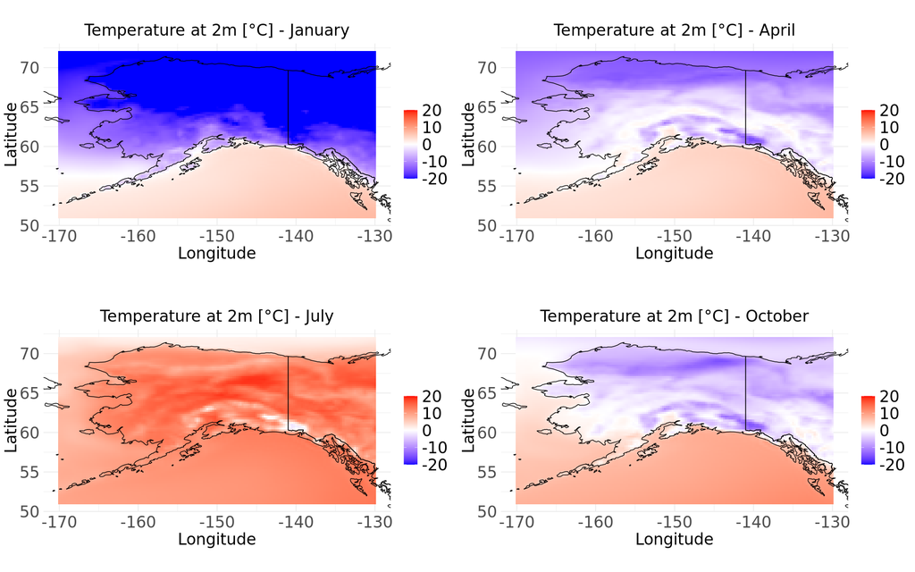

```r
# creating maps
p1=mapping_dataframe(df_climatology_month,index_month=1, c(-20,20),"mean_t2m","Temperature at 2m [°C]")
p2=mapping_dataframe(df_climatology_month,index_month=4, c(-20,20),"mean_t2m","Temperature at 2m [°C]")
p3=mapping_dataframe(df_climatology_month,index_month=7,c(-20,20),"mean_t2m","Temperature at 2m [°C]")
p4=mapping_dataframe(df_climatology_month,index_month=10, c(-20,20),"mean_t2m","Temperature at 2m [°C]")

# Determine figure size
options(repr.plot.width =16, repr.plot.height = 10)
p_total=grid.arrange(p1, p2, p3, p4, ncol = 2, nrow = 2)
```

We can observe a very large variation in temperature in Alaska between winter and summer, with differences of nearly 30°C.

Now we will see the variation between the spring and summer months:

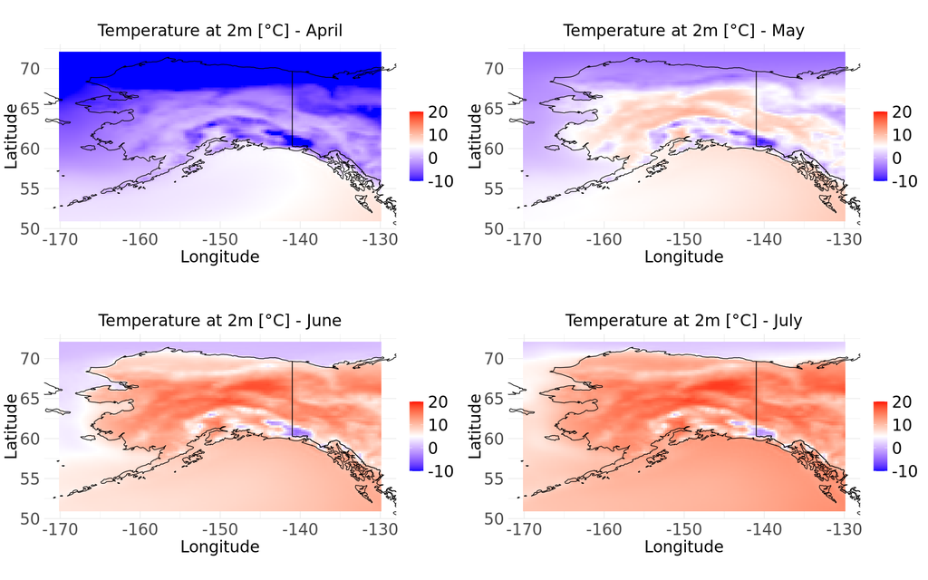

```r
# creating maps
p1=mapping_dataframe(df_climatology_month,index_month=4, c(-10,20),"mean_t2m","Temperature at 2m [°C]")
p2=mapping_dataframe(df_climatology_month,index_month=5, c(-10,20),"mean_t2m","Temperature at 2m [°C]")
p3=mapping_dataframe(df_climatology_month,index_month=6,c(-10,20),"mean_t2m","Temperature at 2m [°C]")
p4=mapping_dataframe(df_climatology_month,index_month=7, c(-10,20),"mean_t2m","Temperature at 2m [°C]")

# Determine figure size
options(repr.plot.width =16, repr.plot.height = 10)
p_total=grid.arrange(p1, p2, p3, p4, ncol = 2, nrow = 2)
```

We have displayed the maps from April to July to examine the seasonal evolution of temperature. A particularly strong increase can be observed between May and June, with temperatures rising significantly across Alaska. This rapid warming can be explained by several factors. First, the amount of incoming solar radiation increases strongly during spring as the days become longer, reaching its maximum around the summer solstice in late June. In addition, the progressive melting and disappearance of the snow cover reduces the surface albedo. As a result, a larger fraction of incoming solar radiation is absorbed by the surface rather than reflected back to the atmosphere. These combined effects contribute to the rapid increase in temperature observed between May and June.

## 5.2. Monthly anomalies maps with 2019

Go back to the "Table of contents"

We will now compare the temperature anomalies from April to July 2019 with the corresponding monthly climatology. To do this, we will extract the 2019 data and calculate the difference between the 2019 temperatures and the monthly climatology calculated over the 2000–2025 period. This will allow us to identify where and during which months temperatures in 2019 were significantly different from the long-term average.

```r
# Monthly mean for 2019
df_month_2019 <- df_climatology %>%
  filter(year == 2019) %>%
  group_by(Longitude, Latitude, month) %>%
  summarise(
    mean_asn  = mean(asn,  na.rm = TRUE),
    mean_t2m  = mean(t2m,  na.rm = TRUE),
    mean_stl1 = mean(stl1, na.rm = TRUE),
    .groups = "drop"
  )
```

```r
# Anomaly: month 2019 - climatological mean
df_anomaly_2019 <- df_climatology_month %>%
  left_join(
    df_month_2019,
    by = c("Longitude", "Latitude", "month"),
    suffix = c("_clim", "_2019")
  ) %>%
  mutate(
    anomaly_asn   = mean_asn_2019   - mean_asn_clim,
    anomaly_t2m  = mean_t2m_2019  - mean_t2m_clim,
    anomaly_stl1 = mean_stl1_2019 - mean_stl1_clim
  )
```

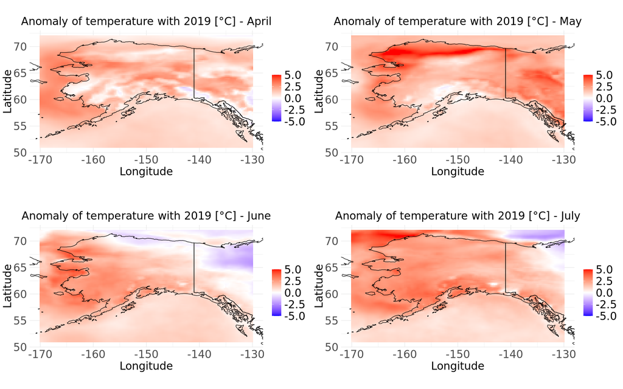

```r
# creating maps
p1=mapping_dataframe(df_anomaly_2019,index_month=4, c(-5,5),"anomaly_t2m","Anomaly of temperature with 2019 [°C]")
p2=mapping_dataframe(df_anomaly_2019,index_month=5, c(-5,5),"anomaly_t2m","Anomaly of temperature with 2019 [°C]")
p3=mapping_dataframe(df_anomaly_2019,index_month=6,c(-5,5),"anomaly_t2m","Anomaly of temperature with 2019 [°C]")
p4=mapping_dataframe(df_anomaly_2019,index_month=7, c(-5,5),"anomaly_t2m","Anomaly of temperature with 2019 [°C]")

# Determine figure size
options(repr.plot.width =16, repr.plot.height = 10)
p_total=grid.arrange(p1, p2, p3, p4, ncol = 2, nrow = 2)
```

We can observe significantly higher temperatures in 2019 from April to July compared with the climatological average. Overall, 2019 was an exceptionally warm year in Alaska, particularly during this spring–summer period.

We will now examine the snow albedo anomaly:

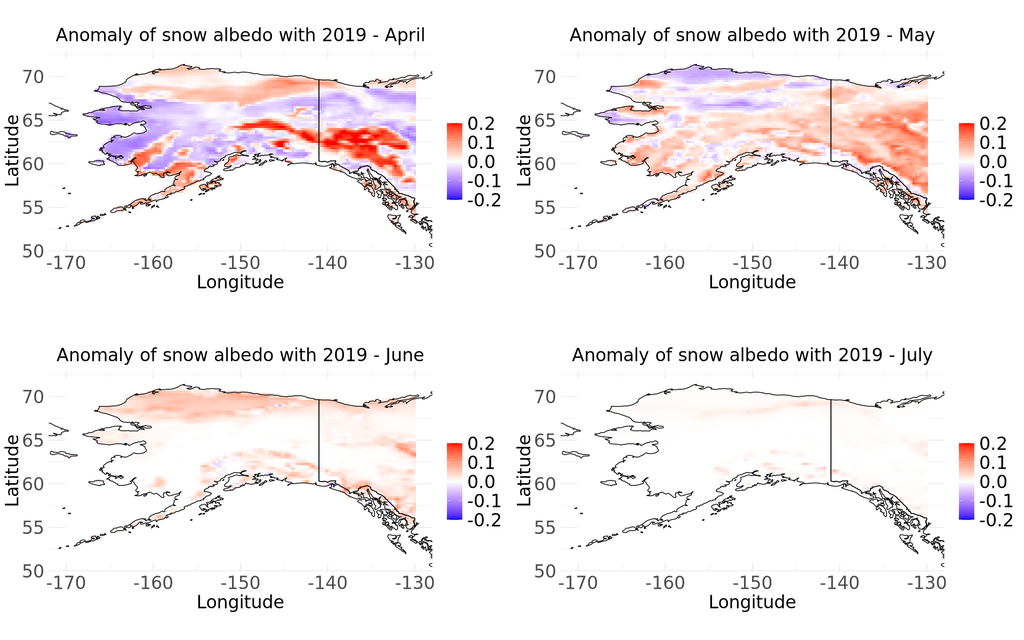

```r
# creating maps
p1=mapping_dataframe(df_anomaly_2019,index_month=4, c(-0.2,0.2),"anomaly_asn","Anomaly of snow albedo with 2019")
p2=mapping_dataframe(df_anomaly_2019,index_month=5, c(-0.2,0.2),"anomaly_asn","Anomaly of snow albedo with 2019")
p3=mapping_dataframe(df_anomaly_2019,index_month=6,c(-0.2,0.2),"anomaly_asn","Anomaly of snow albedo with 2019")
p4=mapping_dataframe(df_anomaly_2019,index_month=7, c(-0.2,0.2),"anomaly_asn","Anomaly of snow albedo with 2019")

# Determine figure size
options(repr.plot.width =16, repr.plot.height = 10)
p_total=grid.arrange(p1, p2, p3, p4, ncol = 2, nrow = 2)
```

The snow albedo anomalies show a strong seasonal variability in 2019. In April, negative anomalies are observed in several areas, indicating that the surface reflected less solar radiation than during the climatological period. However, positive anomalies become more widespread in May and June, while the anomalies are generally close to zero in July. Therefore, the relationship between the exceptionally warm temperatures observed in 2019 and snow albedo is not straightforward and varies throughout the spring–summer transition.

To better understand the potential impact of these albedo changes on the surface energy balance, we will now examine the incoming and net shortwave radiation.

# 6. From snow albedo and surface energy balance

Go back to the "Table of contents"

The previous analysis showed that snow albedo anomalies vary significantly throughout the spring–summer transition, with different patterns observed from April to July. We will now investigate whether these variations are reflected in the surface energy balance. In particular, we will analyse incoming and net shortwave radiation to assess how much solar energy is retained by the surface. Finally, we will compare these results with soil temperature to investigate whether changes in surface energy absorption are associated with increased soil warming.

## 6.1. Comparison between different variables

Go back to the "Table of contents"

```r
# Set the path for the NetCDF files
file <- "./data/reanalysis-era5-single-levels-monthly-means-27c03be7e1f2c45f35a7f45c52b4657f.nc"
```

```r
# Load NetCDF File
data <- nc_open(file)

# Access Data
latitude <- ncvar_get(data, "latitude")  # Name of the latitude variable
longitude <- ncvar_get(data, "longitude")  # Name of the longitude variable

time <- ncvar_get(data, "valid_time")  # Name of the time variable
time_values <- as.POSIXct(time, origin = "1970-01-01", tz = "GMT")

smlt <- ncvar_get(data, "smlt")   # Snow melt
ssr <- ncvar_get(data, "ssr")     # Net shortwave radiation at the surface
ssrd <- ncvar_get(data, "ssrd")   # Downward shortwave radiation at the surface
```

```r
# we create a dataframe
df_energy <- data.frame(expand.grid(longitude, latitude,time_values),
                 smlt = as.vector(smlt[,,]),ssr=as.vector(ssr[,,]),ssrd=as.vector(ssrd[,,]))

names(df_energy) <- c("Longitude", "Latitude","time","smlt","ssr","ssrd")

# add the corresponding month
df_energy$month <- as.numeric(format(df_energy$time, "%m"))
df_energy$year <- as.numeric(format(df_energy$time, "%Y"))

# Statistics over each time
df_energy_month <- df_energy %>%
    group_by(Longitude, Latitude, month) %>%
    reframe(mean_smlt = mean(smlt,na.rm=TRUE),
             mean_ssr = mean(ssr,na.rm=TRUE),
             mean_ssrd = mean(ssrd,na.rm=TRUE))

# Monthly mean for 2019
df_energy_month_2019 <- df_energy %>%
  filter(year == 2019) %>%
  group_by(Longitude, Latitude, month) %>%
  summarise(
    mean_smlt = mean(smlt, na.rm = TRUE),
    mean_ssr = mean(ssr, na.rm = TRUE),
    mean_ssrd = mean(ssrd, na.rm = TRUE),
    .groups = "drop"
  )


# Anomaly: month 2019 - climatological mean
df_energy_anomaly_2019 <- df_energy_month %>%
  left_join(
    df_energy_month_2019,
    by = c("Longitude", "Latitude", "month"),
    suffix = c("_clim", "_2019")
  ) %>%
  mutate(
    anomaly_smlt   = mean_smlt_2019   - mean_smlt_clim,
    anomaly_ssr  = mean_ssr_2019  - mean_ssr_clim,
    anomaly_ssrd = mean_ssrd_2019 - mean_ssrd_clim
  )
```

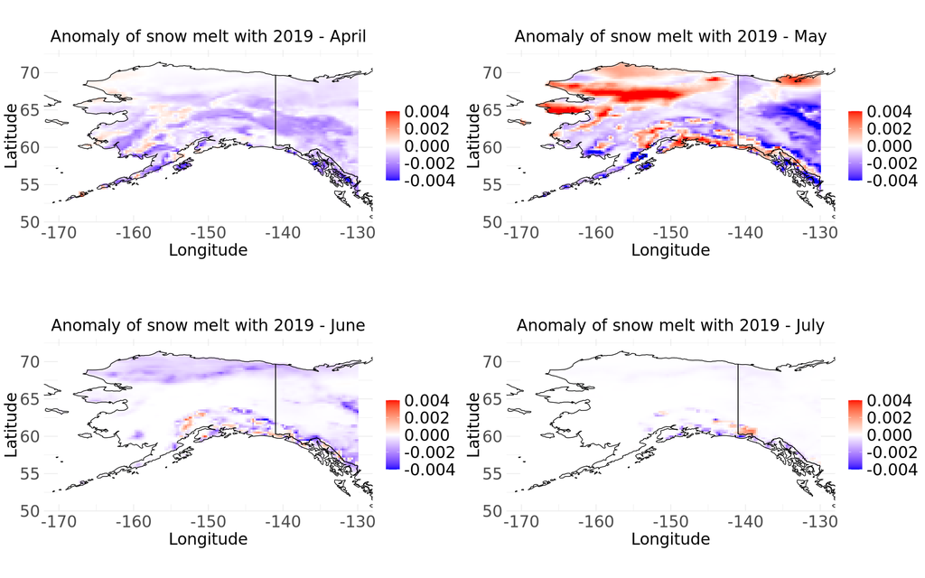

```r
# creating maps of anomaly of snow melt with 2019
p1=mapping_dataframe(df_energy_anomaly_2019,index_month=4, c(-0.004,0.004),"anomaly_smlt","Anomaly of snow melt with 2019")
p2=mapping_dataframe(df_energy_anomaly_2019,index_month=5, c(-0.004,0.004),"anomaly_smlt","Anomaly of snow melt with 2019")
p3=mapping_dataframe(df_energy_anomaly_2019,index_month=6,c(-0.004,0.004),"anomaly_smlt","Anomaly of snow melt with 2019")
p4=mapping_dataframe(df_energy_anomaly_2019,index_month=7, c(-0.004,0.004),"anomaly_smlt","Anomaly of snow melt with 2019")

# Determine figure size
options(repr.plot.width =16, repr.plot.height = 10)
p_total=grid.arrange(p1, p2, p3, p4, ncol = 2, nrow = 2)
```

The snowmelt anomalies show particularly strong snowmelt in May 2019, with positive anomalies across several regions of Alaska. In June, the anomalies become weaker, which does not necessarily mean that less snow melted during the season. Instead, it can indicate earlier snowmelt in 2019, leaving less snow available to melt later in June. Overall, this pattern suggests a shift toward earlier snowmelt during the season.

Now we will focus in June. And compare the diferent variable each other to understant the energy balance in Alaska.

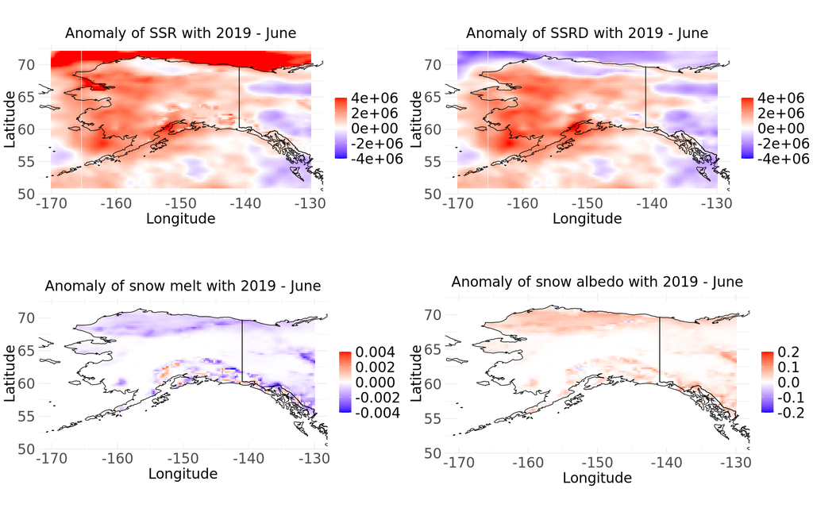

```r
# creating maps
p1=mapping_dataframe(df_energy_anomaly_2019,index_month=6, c(-4000000, 4000000),"anomaly_ssr","Anomaly of SSR with 2019")
p2=mapping_dataframe(df_energy_anomaly_2019,index_month=6, c(-4000000, 4000000),"anomaly_ssrd","Anomaly of SSRD with 2019")
p3=mapping_dataframe(df_energy_anomaly_2019,index_month=6, c(-0.004,0.004),"anomaly_smlt","Anomaly of snow melt with 2019")
p4=mapping_dataframe(df_anomaly_2019,index_month=6, c(-0.2,0.2),"anomaly_asn","Anomaly of snow albedo with 2019")

# Determine figure size
options(repr.plot.width =16, repr.plot.height = 10)
p_total=grid.arrange(p1, p2,p3,p4, ncol = 2, nrow = 2)
```

In June 2019, more incoming solar radiation reached the surface (ssrd positive), and net solar radiation was also higher (ssr positive), indicating that more solar energy was available at the surface. At the same time, snowmelt anomalies were mostly negative or close to zero, while snow albedo was generally higher than the climatological average. This suggests that the snowmelt season may have occurred earlier, leaving less snow available to melt in June, while the surface remained relatively reflective.

And now, we will compare with air and soil temperature:

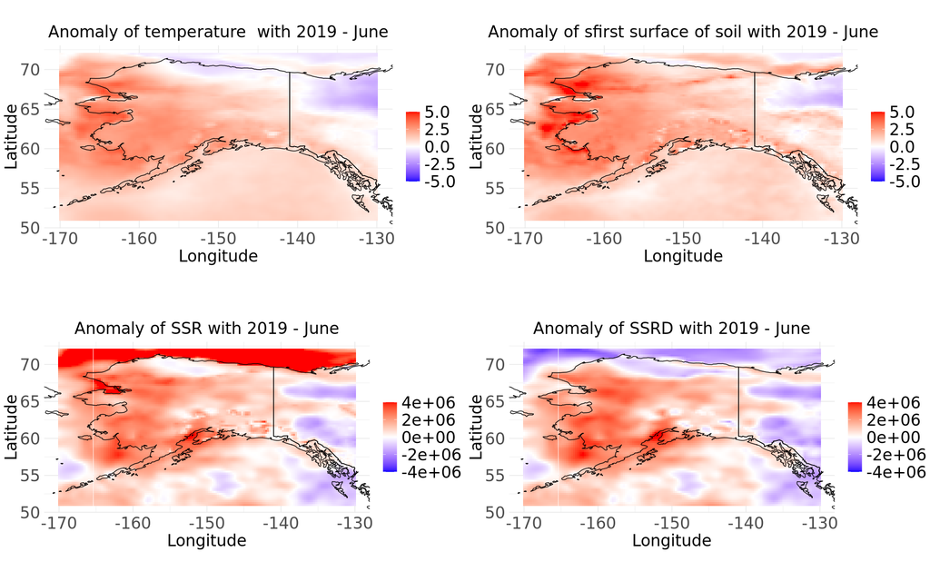

```r
# creating maps
p1=mapping_dataframe(df_anomaly_2019,index_month=6, c(-5,5),"anomaly_t2m","Anomaly of temperature  with 2019")
p2=mapping_dataframe(df_anomaly_2019,index_month=6, c(-5,5),"anomaly_stl1","Anomaly of sfirst surface of soil with 2019")
p3=mapping_dataframe(df_energy_anomaly_2019,index_month=6, c(-4000000, 4000000),"anomaly_ssr","Anomaly of SSR with 2019")
p4=mapping_dataframe(df_energy_anomaly_2019,index_month=6, c(-4000000, 4000000),"anomaly_ssrd","Anomaly of SSRD with 2019")


# Determine figure size
options(repr.plot.width =16, repr.plot.height = 10)
p_total=grid.arrange(p1, p2,p3,p4, ncol = 2, nrow = 2)
```

In June 2019, Alaska experienced higher-than-average air temperatures, together with positive anomalies in incoming (ssrd) and net solar radiation (ssr). At the same time, soil temperature (stl1) was also substantially higher than the climatological average. This suggests that the warmer atmospheric conditions and increased availability of solar energy at the surface were associated with significant soil warming.

## 6.2. Evolution of temperature anomaly in June

Go back to the "Table of contents"

In this part, we will see the evolution of the June month of soil and air temperature anomaly.

```r
# Select June data
df_june <- df_climatology %>%
  filter(month == 6) %>%
  # Group data by year
  group_by(year) %>%
  # Calculate the spatial mean of soil and air temperature for each year
  summarise(
    mean_stl1 = mean(stl1, na.rm = TRUE),
    mean_t2m  = mean(t2m, na.rm = TRUE)
  )
```

```r
# Calculate the climatological mean temperature for June
clim_stl1 <- mean(df_june$mean_stl1, na.rm = TRUE)
clim_t2m  <- mean(df_june$mean_t2m, na.rm = TRUE)
```

```r
# Calculate the June temperature anomalies for each year
df_june <- df_june %>%
  mutate(
    anomaly_stl1 = mean_stl1 - clim_stl1,
    anomaly_t2m  = mean_t2m - clim_t2m
  )
```

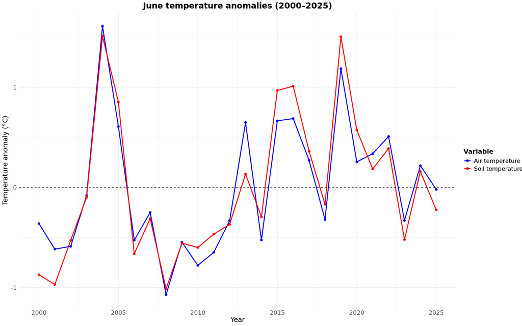

```r
# plotting the time series of June temperature anomalies for both soil and air temperatures
ggplot(df_june, aes(x = year)) +

  # Air temperature anomaly
  geom_line(aes(y = anomaly_t2m, color = "Air temperature"), linewidth = 1) +
  geom_point(aes(y = anomaly_t2m, color = "Air temperature"), size = 2) +

  # Soil temperature anomaly
  geom_line(aes(y = anomaly_stl1, color = "Soil temperature"), linewidth = 1) +
  geom_point(aes(y = anomaly_stl1, color = "Soil temperature"), size = 2) +

  # Zero line = climatological average
  geom_hline(yintercept = 0, linetype = "dashed") +

  # Define colors and legend
  scale_color_manual(
    name = "Variable",
    values = c("Air temperature" = "blue", "Soil temperature" = "red")
  ) +

  # Labels
  labs(
    title = "June temperature anomalies (2000–2025)",
    x = "Year",
    y = "Temperature anomaly (°C)"
  ) +

  # Plot style
  theme_minimal() +
  theme(
    plot.title = element_text(size = 18, face = "bold", hjust = 0.5),
    axis.title = element_text(size = 15),
    axis.text = element_text(size = 13),
    legend.title = element_text(size = 14, face = "bold"),
    legend.text = element_text(size = 13),
    legend.position = "right"
  )
```

The years 2004 and 2019 are among the Junes with the highest air and soil temperature anomalies over the 2000–2025 period. A trend towards increasingly positive anomalies can also be observed from around 2013 onwards. Finally, a strong correlation is observed between air temperature and first-layer soil temperature in June, suggesting that variations in air temperature are closely associated with changes in soil temperature.

## 7. Exercices

Go back to the "Table of contents"

Here is a set of exercises we propose for you to go further into the analysis. There are 3 levels depending on how much R code you need to write to answer the questions.

**Intermediate** :

- In Section 6.2, you can try other months (such as May or August) to show the evolution of air and soil temperatures.

# 8. Conclusion

Go back to the "Table of contents"

**Congratulations!** You have successfully completed the tutorial on using Arctic Hub products to evaluate the temperature anomalies, snow Albedo and surface energy balance in Alaska. Throughout this tutorial, we have explained the basic tools necessary to access and visualize model data, generate different types of plots.

In this tutorial, you acquired all the information you need to:

- Download Copernicus Arctic Hub products.
- Access NetCDF datasets.
- Navigate through the different variables, dimensions and attributes of a NetCDF file.
- Select data subsets within a NetCDF file.
- Compute spatial means of netCDF files to create timeseries.
- Plot maps of any variable.
- Plot time series of data.

We sincerely hope that you have enjoyed the tutorial and found useful information in it. Please keep in mind that the tutorial has a progressive difficulty, moving quickly from basic elements to intermediate levels. Our intention is for all users to find useful information tailored to their level.

We understand that, for a user without prior knowledge, fully understanding all the procedures in the tutorial may be a challenge that requires some effort. However, we encourage everyone to take on the challenge as this is just the beginning of a journey towards a new understanding of the Arctic.

This tutorial is over but we'd love to hear from you about how we could improve it (topics, tools, storytelling, format, speed etc). If you have any question, do not hesitate to contact us via the Copernicus Marine chatbot in the bottom-right corner of any [Copernicus Arctic Hub](https://data.arctic.hub.copernicus.eu/) page.

Credit: This tutorial was created by [NOVELTIS](https://www.noveltis.fr/) under Contract with Mercator Ocean for the Copernicus Arctic Hub.